# RMarkdown Introduction

Tanja

2026-05-06

# R Markdown

This is a short R Markdown document. Markdown is a simple formatting syntax for authoring HTML, PDF, and MS Word documents. For more details on using R Markdown see http://rmarkdown.rstudio.com.

Material from today’s workshop can be found on the [school’s GitHub page](https://github.com/SoSS-UoM).

When analysing data, a starting point is to examine the characteristics of each individual variable in the data set. The way to proceed depends upon the type of variable being examined. The variables can be one of two broad types:

- **Attribute variable**: has its outcomes described in terms of its characteristics or attributes;
  - gender
  - day in a week
- **`Measured variable`**: has the resulting outcome expressed in numerical terms.

## Including R Code

You can embed an R code chunk like this:

```r
# Install if needed (only runs once)
if (!require(palmerpenguins)) install.packages("palmerpenguins")
library(palmerpenguins)

summary(penguins)
penguins[1:10, ]
```

[output not shown]

**Note on messages and warnings**

When you run R code, you may see messages such as:

- package loading messages (e.g. *Attaching package…*)
- warnings (e.g. about missing values or versions)

These are normal and do not usually mean something is wrong.

If you want to hide these in your output, you can use chunk options:

- `message = FALSE` → hides messages
- `warning = FALSE` → hides warnings

For example: `` ```{r, message=FALSE, warning=FALSE} ``

This is often useful when creating clean reports.

## Including Plots

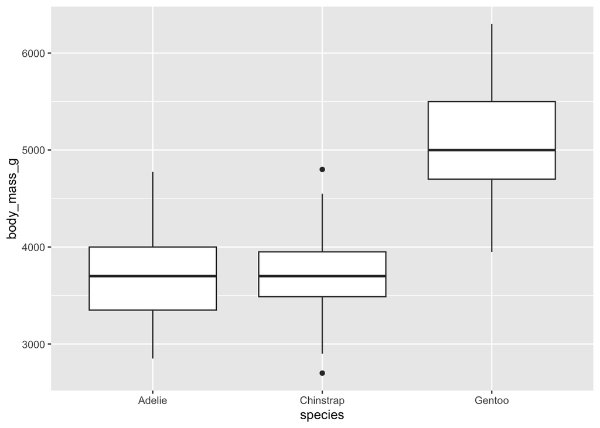

## Including Mathematical Equations

You can include mathematical equations in your document using LaTeX notation.

For example, a simple linear model can be written as:
$$y = b_0 + b_1x_1 + b_2x_2 + ... b_kx_k +
e$$

Let us now fit a model using the `penguins` data:

$$R^2$$

$$R^2_{adj}$$

```r
m1 <- lm(body_mass_g ~ flipper_length_mm, data = penguins)

summary(m1)
```

[output not shown]